# Time normalization for IntelliCages

Roland Bock

October 17, 2021

# Issue

This page provides one solution to a very specific problem, namely realigning observations in one dataframe based on sensor information provided in another dataframe. The data set has been generated using the [IntelliCages](https://www.tse-systems.com/product-details/intellicage/) by [TSE-systems](https://www.tse-systems.com/). They provide an automated system of group-housed mouse behavior over long periods of time, only interrupted by required cage changes. If one of the desired analysis is the drinking behavior over time, it is desirable to express the time in relation to the light-dark cycle. In many cases, this can be simply achieved by relabeling the time axis according to the light-dark cycle. In other cases, as in the one that prompted this solution, it is not quite as straight forward. In this example, the recording went through the time shift from standard time to daylight savings time, i.e. the light-dark cycle within the facility did not change, but the computer automatically (per default) adjusted it’s own time to the daylight savings time. Although nothing changed for the individual animal, a histogram on the visit or nosepoke times will show a time shift.

# Prerequisite

This is not an explanation of the full functionality of the Intellicages. The example data for this solution are exported text files from the IntelliCage Analyzer Program, which creates 7 or 8 distinct files, but only a subset are included here:

- **Animal**.txt - summary for each animal
- **Environment**.txt - enviroment data for temperature and illumination
- **Visit**.txt - summary of the visit events

For detailed explanations, please refer to the help sections on your own IntelliCage system.

# Goal

The goal of these steps is to recalculate each visit timestamp relative to the beginning of its dark cycle. The same procedure can be used for the nosepoke data, which are not included here.

# Problem visualized

To start I am going to visualize the problem. Let’s begin with loading some neccessary packages.

```r
library(easypackages)
packages("tidyverse", "patchwork", "kableExtra", "here", "lubridate",
         "labelled", "hms")
```

## The data

Initially the data frame needs to be constructed by combining the individual visit records with the data in the animal table, so the correct grouping can be used. Otherwise the data from the visits file could be used without any joining.

### Animals

First load the animal data, so that we can use the assigned groups for the visit data. This data is loaded from a separate csv file to make reassigning the groups easier.

```r
subjects <- read_csv(file = here("data", "animal_overview.csv"), col_names = T,
                       col_type = "ccccic")
subjects$Group <- factor(subjects$Group, levels = c("control", "autokn", "idkn", "ddkn"))
subjects$DOB <- as.Date(subjects$DOB, "%m/%d/%y")
subjects <- rename(subjects, Tag = RFID)
var_label(subjects) <- list(Animal = "Mouse ID number",
                              Sex = "Sex",
                              DOB = "Date of birth",
                              Tag = "Chip ID number",
                              Cohort = "Cohort number",
                              Group = "Experimental group")

subjects %>%
  arrange(Group, Sex) %>%
  kable(caption = "Overview of experimental animals") %>%
  kable_classic(lightable_options = "hover", font_size = 14, full_width = F)
```

Overview of experimental animals

| Animal | Sex | DOB | Tag | Cohort | Group |
| --- | --- | --- | --- | --- | --- |
| B56855 | F | 2020-12-31 | 900200000632423 | 1 | control |
| B56884 | F | 2021-01-01 | 900200000636135 | 1 | control |
| B56886 | F | 2021-01-01 | 900200000636861 | 1 | control |
| B56595 | M | 2020-12-28 | 900200000633514 | 1 | control |
| B56858 | M | 2020-12-31 | 900200000633005 | 1 | control |
| B56888 | M | 2021-01-01 | 900200000634000 | 1 | control |
| B56856 | F | 2020-12-31 | 900200000634210 | 1 | autokn |
| B56857 | F | 2020-12-31 | 900200000633862 | 1 | autokn |
| B56596 | M | 2020-12-28 | 992000000490050 | 1 | autokn |
| B56860 | M | 2020-12-31 | 900200000634524 | 1 | autokn |
| B56887 | M | 2021-01-01 | 900200000633904 | 1 | autokn |
| B56594 | F | 2020-12-28 | 992000000492353 | 1 | idkn |
| B56883 | F | 2021-01-01 | 900200000634896 | 1 | idkn |
| B56885 | F | 2021-01-01 | 900200000633897 | 1 | idkn |
| B56889 | M | 2021-01-01 | 900200000632876 | 1 | idkn |
| B56859 | M | 2020-12-31 | 900200000633546 | 1 | ddkn |
| B56890 | M | 2021-01-01 | 900200000633314 | 1 | ddkn |

### Visits

Next load the *Visit.txt* file with the summary data for each registered visit.

```r
visits.col.spec <- cols(
  .default = col_integer(),
  VisitID = col_integer(),
  VisitOrder = col_integer(),
  Animal = col_character(),
  Tag = col_character(),
  Sex = col_character(),
  Group = col_character(),
  Module = col_character(),
  Cage = col_integer(),
  Corner = col_integer(),
  CornerCondition = col_factor(),
  PlaceError = col_logical(),
  SideErrors = col_double(),
  TimeErrors = col_double(),
  ConditionErrors = col_double(),
  NosepokeNumber = col_double(),
  NosepokeDuration = col_double(),
  LickNumber = col_double(),
  LickDuration = col_double(),
  LickContactTime = col_double(),
  StartDate = col_date(),
  StartTime = col_time(),
  StartTimecode = col_double(),
  EndDate = col_date(),
  EndTime = col_time(),
  EndTimecode = col_double(),
  VisitDuration = col_double(),
  Session = col_integer()
)

visitData <- read_tsv(file = here("data/Cohort 1/", "Visit.txt"), col_types = visits.col.spec)

tibble(variables = ncol(visitData),
       sessions = nlevels(as.factor(visitData$Session)),
       start = min(visitData$StartDate),
       end = max(visitData$EndDate),
       visits = format(nrow(visitData), big.mark = ",", justify = "right"),
       pokes = format(sum(visitData$NosepokeNumber), big.mark = ","),
       licks = format(sum(visitData$LickNumber), big.mark = ",")) %>%
  kable(caption = "Quick visit data overview") %>%
  kable_paper(font_size = 14)
```

Quick visit data overview

| variables | sessions | start | end | visits | pokes | licks |
| --- | --- | --- | --- | --- | --- | --- |
| 29 | 7 | 2021-02-16 | 2021-03-29 | 119,111 | 476,946 | 1,898,926 |

In the next step I am combining the *subject* data frame with the *visitData* data frame, mainly to update the grouping.

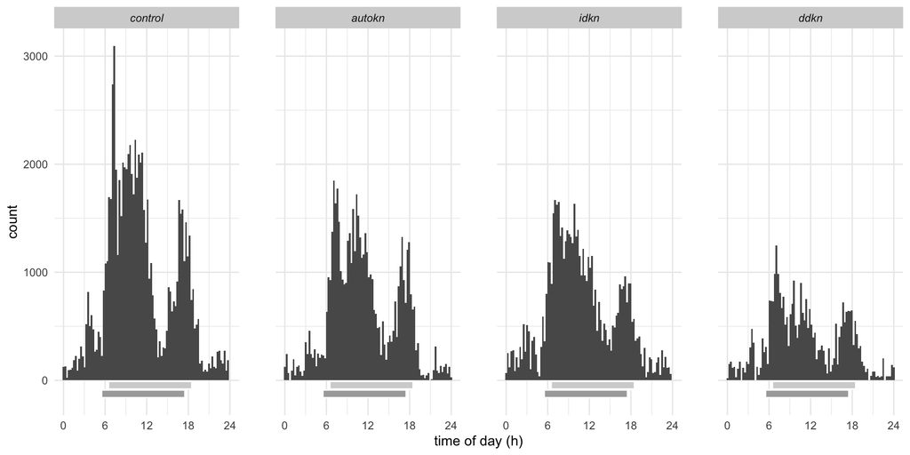

Alcohol drinking pattern of 4 groups of mice during the day with a reversed light-dark cycle over the course of 6 weeks. Darkgray bar indicates recorded dark cycle during standard time, lightgray bar shows dark cycle during daylight savings time. The light cycle did not change for the mice, the computer adjusted its recording time by default.

```r
visitsAll <- subjects %>%
  select(Tag, Group) %>%            # select only the Tag and Group column from the subjects
  left_join(visitData %>% select(-c(Group)), by = "Tag") %>%      # join with visit data and drop the group column
  mutate(drink = if_else(Session > 1 & (Corner == 2 | Corner == 4), "alcohol", "water")) # introduce a drink
                                                                                         # label for the corners
visitsAll %>%
  filter(LickNumber > 0 & drink == "alcohol") %>%

  ggplot(aes(x = StartTime, weight = LickNumber)) +
  geom_histogram(bins = 96) +
  geom_rect(aes(xmin = as_hms("6:30:00"),
                xmax = as_hms("18:30:00"), ymin = -80, ymax = -10),
            color = "white", fill = "lightgray") +
  geom_rect(aes(xmin = as_hms("5:30:00"),
                xmax = as_hms("17:30:00"), ymin = -160, ymax = -90),
            color = "white", fill = "darkgray") +
  scale_x_time(name = "time of day (h)",
               breaks = seq(0, 24 * 3600, 6 * 3600),
               labels = seq(0, 24, 6)) +
  theme_minimal() +
  theme(strip.background = element_rect(color = "lightgray", fill = "lightgray"),
        strip.text = element_text(face = "italic"),
        panel.spacing = unit(2, "lines")) +
  facet_grid(. ~ Group)
```

Ideally the recording becomes independent from the computer time and can be expressed as a relative unit from the beginning of the dark or light cycle.

# Solution

## The easy way

The quick way out is to remember when the time shift happened and to manually adjust the times and dates in the visits data table. In this case, the switch from standard time to daylight savings time happened on *3/14/2021* at *2:00 a.m.*

One way is to create a datetime column by combining the start date and time and then subtract one hour from each observation after the time switch happened.

```r
# combine the individual data and time columns into a datetime start column for each observation
visitsAll <- visitsAll %>%
  mutate(StartTStamp = make_datetime(year = year(StartDate), month = month(StartDate),
                                     day = day(StartDate), hour = hour(StartTime),
                                     min = minute(StartTime), sec = second(StartTime)))
```

Before we continue further, let’s just have a quick peak at the distribution of observations before and after the time change.

```r
tibble(standard = nrow(visitsAll %>% filter(StartTStamp < ymd_hms("2021-03-14 02:00:00"))),
       perc_standard = standard / nrow(visitsAll) * 100,
       daylight_savings = nrow(visitsAll %>% filter(StartTStamp > ymd_hms("2021-03-14 02:00:00"))),
       per_daylight = daylight_savings / nrow(visitsAll) * 100,
       total = nrow(visitsAll)) %>%
  kable(caption = "Distribution of observations before and after time switch",
        digits = 1, format.args = list(big.mark = ","),
        col.names = c("standard time", "%", "daylight savings time", "%", "total")) %>%
  kable_paper(font_size = 14)
```

Distribution of observations before and after time switch

| standard time | % | daylight savings time | % | total |
| --- | --- | --- | --- | --- |
| 73,241 | 61.5 | 45,870 | 38.5 | 119,111 |

The `lubridate` package takes care of the correct time handling especially at the day boundaries.

```r
visitsAll <- visitsAll %>%
  mutate(adjustedDT = if_else(StartTStamp > ymd_hms("2021-03-14 02:00:00"),
                              StartTStamp - hours(1), StartTStamp),
         adjustedT = as_hms(adjustedDT))
```

The result be seen in the graph below.

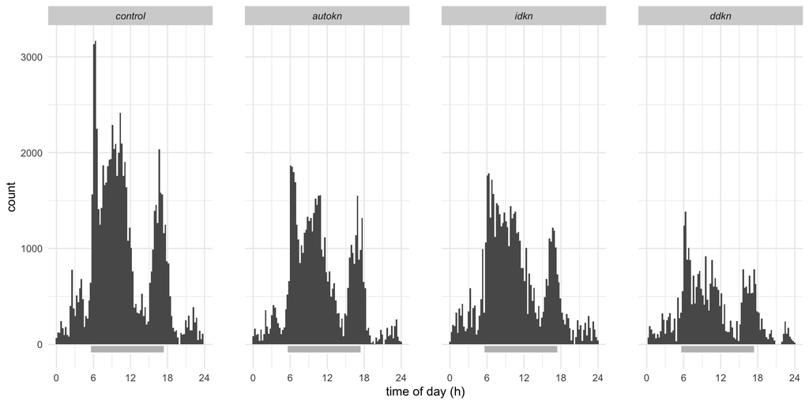

Histogram with corrected visit times.

```r
visitsAll %>%
  filter(LickNumber > 0 & drink == "alcohol") %>%

  ggplot(aes(x = adjustedT, weight = LickNumber)) +
  geom_histogram(bins = 96) +
  geom_rect(aes(xmin = as_hms("5:30:00"),
                xmax = as_hms("17:30:00"), ymin = -90, ymax = -10),
            color = "white", fill = "gray") +
  scale_x_time(name = "time of day (h)",
               breaks = seq(0, 24 * 3600, 6 * 3600),
               labels = seq(0, 24, 6)) +
  theme_minimal() +
  theme(strip.background = element_rect(color = "lightgray", fill = "lightgray"),
        strip.text = element_text(face = "italic"),
        panel.spacing = unit(2, "lines")) +
  facet_grid(. ~ Group)
```

## The alternate way

Each IntelliCage has a build-in illumination and temperature sensor. The default setting records the illumination and temperature once a minute. Using the functionality of the [tidyverse](https://www.tidyverse.org/), we can extract the start times of the dark cycle, merge them back into the visit or nosepoke data file and calculate the individual offset for each observation.

The advantage of this approach is that (1) nobody has to remember when the time shift happened, especially if the data set gets revisited at a later time and (2) have a much better alignment of the data being expressed relative to the recorded light cycle. Any unsuspected shifts or irregularities will be automatically aligned.

The data for the temperature and illumination are stored in the *environment.txt* file. It can be loaded as follows:

```r
environment.col.spec <- cols(
  .default = col_integer(),
  DateTime = col_datetime(),
  Temperature = col_double(),
  Illumination = col_integer(),
  Cage = col_integer()
)

env <- read_tsv(file = here("data/Cohort 1/", "Environment.txt"),
                         col_types = environment.col.spec) %>%
  mutate(date = as.Date(DateTime, "%Y-%m-%d"),               # extracting the date
         time = as_hms(format(DateTime, "%H:%M:%S")))        #   and time in extra columns

glimpse(env)
```

```
## Rows: 111,678
## Columns: 6
## $ DateTime     <dttm> 2021-02-16 13:23:38, 2021-02-16 13:23:38, 2021-02-16 13:…
## $ Temperature  <dbl> 24.4, 25.4, 24.4, 25.4, 24.4, 25.4, 24.4, 25.4, 24.4, 25.…
## $ Illumination <int> 0, 0, 0, 0, 0, 0, 0, 0, 0, 0, 0, 0, 0, 0, 0, 0, 0, 0, 0, …
## $ Cage         <int> 1, 2, 1, 2, 1, 2, 1, 2, 1, 2, 1, 2, 1, 2, 1, 2, 1, 2, 1, …
## $ date         <date> 2021-02-16, 2021-02-16, 2021-02-16, 2021-02-16, 2021-02-…
## $ time         <time> 13:23:38, 13:23:38, 13:24:38, 13:24:38, 13:25:38, 13:25:…
```

The recorded data should be quite the same for both cages, since they are in the same room. I am also just interested in the illumination value, so we can further drop the *Temperature* and the *DateTime* column.

```r
env <- env %>% filter(Cage == 1) %>% select(Illumination, date, time)
```

### (1) Find all start times of the dark cycle

Start by categorizing the Illumination value as either ON or OFF for values above or below 5. This will be specific to the calibration of each individual system. Then calculate the change to the previous value. A negative change (in this case -10) indicates the first time stamp of the dark phase.

```r
envDark <- env %>%
  mutate(Illumination = if_else(Illumination < 5, 0, 10),      # clean Illumination values and
         IllChange = Illumination - lag(Illumination))  %>%    #    calculate the change
  filter(IllChange < 0) %>%
  mutate(darkStart = time)                                     # need an extra column for start time

envDark %>%
  slice_head(n = 5) %>%
  kable(caption = "First rows of new environmental data table.") %>%
  kable_paper(font_size = 14, full_width = F)
```

First rows of new environmental data table.

| Illumination | date | time | IllChange | darkStart |
| --- | --- | --- | --- | --- |
| 0 | 2021-02-17 | 05:36:41 | -10 | 05:36:41 |
| 0 | 2021-02-18 | 05:36:45 | -10 | 05:36:45 |
| 0 | 2021-02-19 | 05:35:49 | -10 | 05:35:49 |
| 0 | 2021-02-20 | 05:35:53 | -10 | 05:35:53 |
| 0 | 2021-02-21 | 05:35:57 | -10 | 05:35:57 |

As a good measure, lets perform quick sanity check to make sure all data points are consistent.

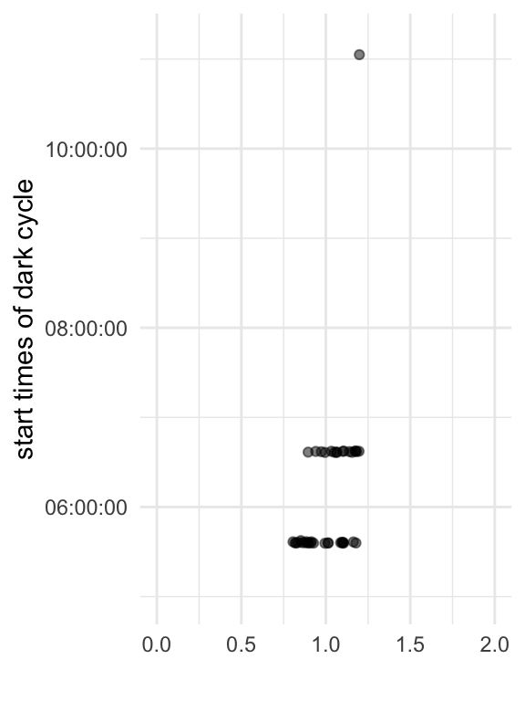

A single outlier of the start times indicate that somebody turned the light on during the dark cycle.

```r
envDark %>%
  ggplot(aes(x = 1, y = darkStart)) +
  geom_jitter(width = 0.2, shape = 19, fill = "gray", alpha = 0.5) +
  scale_x_continuous(name = "", limits = c(0, 2)) +
  scale_y_time(name = "start times of dark cycle",
               limits = c(5 * 3600, 11.2 * 3600)) +
  theme_minimal()
```

Let’s remove the single outlier before we merge the start times back into the visits data frame.

```r
envDark <- envDark %>% filter(time < as_hms("10:00:00"))
```

In this case I am interested in the start of the dark cycle, though the initial start of the program is in the middle of the dark cycle. We need to find the first start of the light cycle, subtract 12 hours from it and add it to the top of the table.

```r
env %>%
  mutate(Illumination = if_else(Illumination < 5, 0, 10),      # clean Illumination values and
         IllChange = Illumination - lag(Illumination))  %>%    #    calculate the change
  filter(IllChange > 0) %>%               # find all the light starts
  slice_head() %>%                        # limit to the first one
  mutate(time = as_hms(time - 12*60*60),  # subtract 12 hours from start time
         IllChange = -IllChange,
         Illumination = 0,
         darkStart = time) %>%
  bind_rows(., envDark) -> envDark

envDark %>%
  slice_head(n = 5) %>%
  kable(caption = "Data table with added first row") %>%
  kable_paper(font_size = 14, full_width = F)
```

Data table with added first row

| Illumination | date | time | IllChange | darkStart |
| --- | --- | --- | --- | --- |
| 0 | 2021-02-16 | 05:35:38 | -10 | 05:35:38 |
| 0 | 2021-02-17 | 05:36:41 | -10 | 05:36:41 |
| 0 | 2021-02-18 | 05:36:45 | -10 | 05:36:45 |
| 0 | 2021-02-19 | 05:35:49 | -10 | 05:35:49 |
| 0 | 2021-02-20 | 05:35:53 | -10 | 05:35:53 |

### (2) Add dark cycle times to timestamps for visits

Now we need to get the time stamps for the visit data and match them with the correct dark cycle start time.

```r
visitsDT <- visitsAll %>%
  select(StartDate, StartTime) %>%
  rename(date = "StartDate", time = "StartTime")

visitsDT <- visitsDT %>%
  bind_rows(envDark) %>%
  arrange(date, time) %>%                  # sort all data rows by date and time
  fill(darkStart, .direction = "down") %>% # fill the missing values
  select(-c(Illumination, IllChange))      # columns are not needed anymore
```

### (3) Use the dark cycle start times to adjust start times

```r
visitsCor <- visitsAll %>%
  inner_join(visitsDT, by = c(StartDate = "date", StartTime = "time")) %>%
  mutate(dark = as_hms(StartTime - darkStart))
```

## Corrected Graph

As the following graph shows, the subtraction of the start time of the dark cycle produces negative times for all observations between midnight and the start of the dark cycle. This was done on purpose to be able to show the lead-up to the dark cycle at time 0.

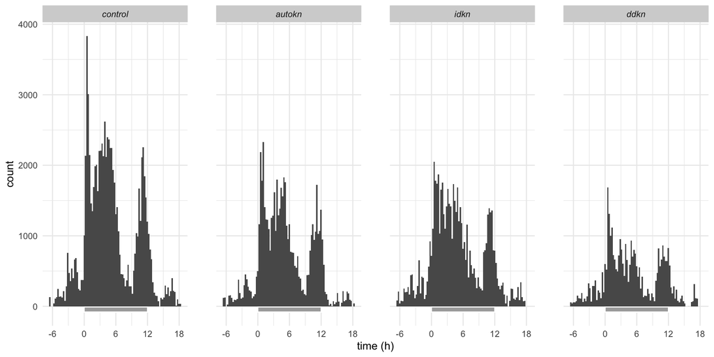

Alcohol drinking data plotted against corrected times. Time 0 is the start of the dark cycle.

```r
visitsCor %>%
  filter(LickNumber > 0 & drink == "alcohol") %>%

  ggplot(aes(x = dark, weight = LickNumber)) +
  geom_histogram(bins = 96) +
  geom_rect(aes(xmin = as_hms("0:00:00"),
                xmax = as_hms("12:00:00"), ymin = -80, ymax = -10),
            color = "white", fill = "darkgray") +
  scale_x_time(name = "time (h)",
               breaks = seq(-6 * 3600, 18 * 3600, 6 * 3600),
               labels = seq(-6, 18, 6)) +
  theme_minimal() +
  theme(strip.background = element_rect(color = "lightgray", fill = "lightgray"),
        strip.text = element_text(face = "italic"),
        panel.spacing = unit(2, "lines")) +
  facet_grid(. ~ Group)
```

If the negative times are unwanted, they can simply be transformed back into a 24 hour cycle by adding all negative times to 24 hours (and subtract one day from the date).

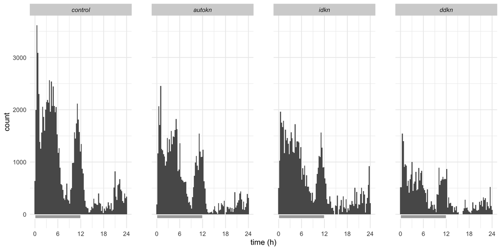

Histogram with times aligned to the 24 hour cycle.

```r
visitsCor %>%
  mutate(dark_d = if_else(dark < 0, StartDate - 1, StartDate),
         dark_t = if_else(dark < 0, as_hms(24 * 3600 + dark), dark)) %>%
  filter(LickNumber > 0 & drink == "alcohol") %>%

  ggplot(aes(x = dark_t, weight = LickNumber)) +
  geom_histogram(bins = 96) +
  geom_rect(aes(xmin = as_hms("0:00:00"),
                xmax = as_hms("12:00:00"), ymin = -80, ymax = -10),
            color = "white", fill = "darkgray") +
  scale_x_time(name = "time (h)",
               breaks = seq(0, 24 * 3600, 6 * 3600),
               labels = seq(0, 24, 6)) +
  theme_minimal() +
  theme(strip.background = element_rect(color = "lightgray", fill = "lightgray"),
        strip.text = element_text(face = "italic"),
        panel.spacing = unit(2, "lines")) +
  facet_grid(. ~ Group)
```

Violá - all data aligned using system-intrinsic sensors. Issues and errors can be logged on the [github](https://github.com/r-bock/ic-time-normalizer) page for this repository.